# Part I - Exploratory Analysis of Ford GoBike Trip Data

## Introduction

> This data set includes information about individual rides made in a bike-sharing system in February 2019 covering the greater San Francisco Bay area.

## Preliminary Wrangling

```python
# import all packages and set plots to be embedded inline
import numpy as np
import pandas as pd
import matplotlib.pyplot as plt
import seaborn as sb

%matplotlib inline
```

```python
bike_data = pd.read_csv('201902-fordgobike-tripdata.csv')
```

```python
bike_data.head()
```

|  | duration_sec | start_time | end_time | start_station_id | start_station_name | start_station_latitude | start_station_longitude | end_station_id | end_station_name | end_station_latitude | end_station_longitude | bike_id | user_type | member_birth_year | member_gender | bike_share_for_all_trip |
| --- | --- | --- | --- | --- | --- | --- | --- | --- | --- | --- | --- | --- | --- | --- | --- | --- |
| 0 | 52185 | 2019-02-28 17:32:10.1450 | 2019-03-01 08:01:55.9750 | 21.0 | Montgomery St BART Station (Market St at 2nd St) | 37.789625 | -122.400811 | 13.0 | Commercial St at Montgomery St | 37.794231 | -122.402923 | 4902 | Customer | 1984.0 | Male | No |
| 1 | 42521 | 2019-02-28 18:53:21.7890 | 2019-03-01 06:42:03.0560 | 23.0 | The Embarcadero at Steuart St | 37.791464 | -122.391034 | 81.0 | Berry St at 4th St | 37.775880 | -122.393170 | 2535 | Customer | NaN | NaN | No |
| 2 | 61854 | 2019-02-28 12:13:13.2180 | 2019-03-01 05:24:08.1460 | 86.0 | Market St at Dolores St | 37.769305 | -122.426826 | 3.0 | Powell St BART Station (Market St at 4th St) | 37.786375 | -122.404904 | 5905 | Customer | 1972.0 | Male | No |
| 3 | 36490 | 2019-02-28 17:54:26.0100 | 2019-03-01 04:02:36.8420 | 375.0 | Grove St at Masonic Ave | 37.774836 | -122.446546 | 70.0 | Central Ave at Fell St | 37.773311 | -122.444293 | 6638 | Subscriber | 1989.0 | Other | No |
| 4 | 1585 | 2019-02-28 23:54:18.5490 | 2019-03-01 00:20:44.0740 | 7.0 | Frank H Ogawa Plaza | 37.804562 | -122.271738 | 222.0 | 10th Ave at E 15th St | 37.792714 | -122.248780 | 4898 | Subscriber | 1974.0 | Male | Yes |

```python
bike_data.shape
```

```
(183412, 16)
```

```python
bike_data.describe()
```

|  | duration_sec | start_station_id | start_station_latitude | start_station_longitude | end_station_id | end_station_latitude | end_station_longitude | bike_id | member_birth_year |
| --- | --- | --- | --- | --- | --- | --- | --- | --- | --- |
| count | 183412.000000 | 183215.000000 | 183412.000000 | 183412.000000 | 183215.000000 | 183412.000000 | 183412.000000 | 183412.000000 | 175147.000000 |
| mean | 726.078435 | 138.590427 | 37.771223 | -122.352664 | 136.249123 | 37.771427 | -122.352250 | 4472.906375 | 1984.806437 |
| std | 1794.389780 | 111.778864 | 0.099581 | 0.117097 | 111.515131 | 0.099490 | 0.116673 | 1664.383394 | 10.116689 |
| min | 61.000000 | 3.000000 | 37.317298 | -122.453704 | 3.000000 | 37.317298 | -122.453704 | 11.000000 | 1878.000000 |
| 25% | 325.000000 | 47.000000 | 37.770083 | -122.412408 | 44.000000 | 37.770407 | -122.411726 | 3777.000000 | 1980.000000 |
| 50% | 514.000000 | 104.000000 | 37.780760 | -122.398285 | 100.000000 | 37.781010 | -122.398279 | 4958.000000 | 1987.000000 |
| 75% | 796.000000 | 239.000000 | 37.797280 | -122.286533 | 235.000000 | 37.797320 | -122.288045 | 5502.000000 | 1992.000000 |
| max | 85444.000000 | 398.000000 | 37.880222 | -121.874119 | 398.000000 | 37.880222 | -121.874119 | 6645.000000 | 2001.000000 |

```python
bike_data.info()
```

```
<class 'pandas.core.frame.DataFrame'>
RangeIndex: 183412 entries, 0 to 183411
Data columns (total 16 columns):
 #   Column                   Non-Null Count   Dtype
---  ------                   --------------   -----
 0   duration_sec             183412 non-null  int64
 1   start_time               183412 non-null  object
 2   end_time                 183412 non-null  object
 3   start_station_id         183215 non-null  float64
 4   start_station_name       183215 non-null  object
 5   start_station_latitude   183412 non-null  float64
 6   start_station_longitude  183412 non-null  float64
 7   end_station_id           183215 non-null  float64
 8   end_station_name         183215 non-null  object
 9   end_station_latitude     183412 non-null  float64
 10  end_station_longitude    183412 non-null  float64
 11  bike_id                  183412 non-null  int64
 12  user_type                183412 non-null  object
 13  member_birth_year        175147 non-null  float64
 14  member_gender            175147 non-null  object
 15  bike_share_for_all_trip  183412 non-null  object
dtypes: float64(7), int64(2), object(7)
memory usage: 22.4+ MB
```

### What is the structure of your dataset?

> There are 183,412 individual rides in this dataset with 16 features(duration_sec, start_time, end_time, start_station_id, start_station_name, start_station_latitude, start_station_longitude, end_station_id, end_station_name, end_station_latitude, end_station_longitude, bike_id, user_type, member_birth_year, member_gender and bike_share_for_all_trip). Most of the features are numerical while the rest are either categorical or datetime objects.

### What is/are the main feature(s) of interest in your dataset?

> The main feature of interest is the duration of rides. I want to figure out which features determine time taken for rides will be(i.e short or long rides)

### What features in the dataset do you think will help support your investigation into your feature(s) of interest?

> I think the user_type, member_birth_year, bike_share_for_all_trip and member_gender,start_time(day and time) will help to support my investigation

```python
#Make a copy of the bike_data
df = bike_data.copy()
```

```python
#Replace 1878(likely an error) with 1978
df['member_birth_year'] = df['member_birth_year'].replace(1878, 1978)

# Fill the missing values with the mean
df['member_birth_year'].fillna(int(df['member_birth_year'].mean()), inplace=True)

#Convert datatype to int
df['member_birth_year'] = df['member_birth_year'].astype('int')
```

```python
#Fill missing gender with the mode which is male
df['member_gender'].fillna("Male", inplace=True)

df['member_gender'] = df['member_gender'].astype('category')
```

```python
df['user_type'] = df['user_type'].astype('category')
df['member_gender'] = df['member_gender'].astype('category')
df['bike_share_for_all_trip'] = df['bike_share_for_all_trip'].astype('category')
```

```python
#Convert start_time and end_time to datetime objects
df['start_time'] = pd.to_datetime(df['start_time'])
df['end_time'] = pd.to_datetime(df['end_time'])
```

```python
df['duration_min'] = df['duration_sec']/ 60
```

```python
#Calculate age from birth year
df['member_age'] = 2019 - df['member_birth_year']
df['member_age'] = df['member_age'].astype('int')
```

```python
df['Day_of_week'] = df['start_time'].dt.strftime('%A')
```

```python
df['time'] = df['start_time'].dt.strftime('%H')
```

Firstly, let's look at the distribution of the duration of bike trips in minutes

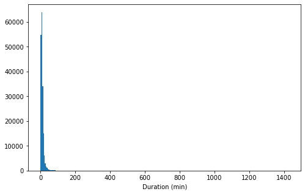

```python
bins = np.arange(1, df['duration_min'].max()+5,5)

plt.figure(figsize=[8, 5])
plt.hist(data=df, x='duration_min',bins=bins)
plt.xlabel('Duration (min)')
plt.show()
```

The distribution is right skewed and has a long tail. Let's plot it on a log-scale so we can remove the skewness and see the distribution clearly.

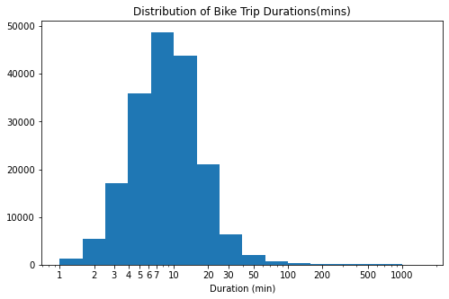

```python
bins = 10 ** np.arange(np.log10(1), np.log10(df['duration_min'].max())+0.2,0.2)

plt.figure(figsize=[8, 5])
plt.hist(data=df, x='duration_min',bins=bins)
plt.xscale('log')  #log transfrormation
plt.xticks([1,2,3,4,5,6,7,10,20,30,50,100,200,500,1000], [1,2,3,4,5,6,7,10,20,30,50,100,200,500,1000])
plt.xlabel('Duration (min)')
plt.title("Distribution of Bike Trip Durations(mins)")
plt.show();
```

The modal duration is between 7 and 10 minutes. There are very few rides with durations more than 70 minutes.

Next, let's take a look at the age distribution of the members.

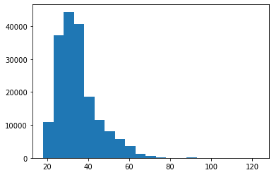

```python
bins = np.arange(18, df['member_age'].max()+5, 5)
plt.hist(data=df, x='member_age', bins=bins)

plt.show()
```

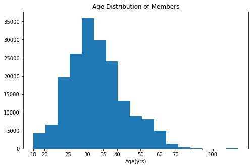

```python
bins = 10 ** np.arange(np.log10(18), np.log10(df['member_age'].max())+0.05,0.05)

plt.figure(figsize=[8, 5])
plt.hist(data=df, x='member_age', bins=bins);
plt.xscale("log") # log transformation
plt.xticks([18,20,25,30,35,40,50,60,70,100], [18,20,25,30,35,40,50,60,70,100])
plt.xlabel("Age(yrs)")
plt.title("Age Distribution of Members")
plt.show()
```

Most of the members are between the age 25 and 40 years. The modal age is between 29 and 32 years.

```python
base_color = sb.color_palette()[0]
```

#### What user type is most common?

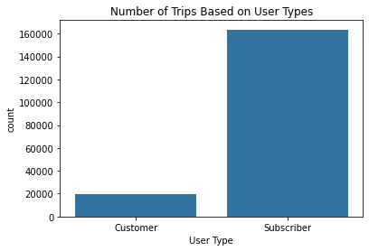

```python
sb.countplot(data=df, x='user_type', color=base_color)
plt.title("Number of Trips Based on User Types")
plt.xlabel("User Type");
```

89.2% of the users are subscribers while the remaining 10.8% are customers. Therefore, subscribers are more common.

#### What member gender takes the most trips?

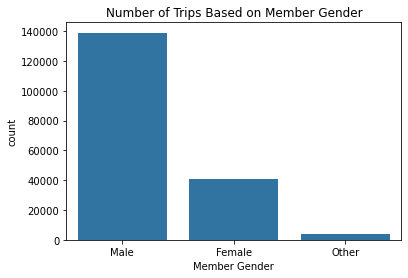

```python
sb.countplot(data=df, x='member_gender', color=base_color, order=bike_data['member_gender'].value_counts().index)
plt.title("Number of Trips Based on Member Gender")
plt.xlabel("Member Gender")
plt.show()
```

The most common gender among the members is Male (75.7%).

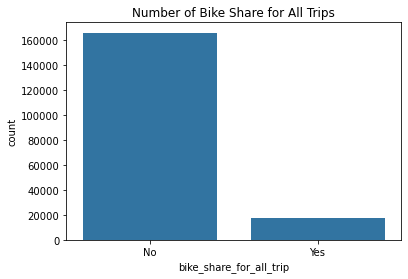

```python
sb.countplot(data=df, x='bike_share_for_all_trip', color=base_color)
plt.title("Number of Bike Share for All Trips");
```

```python
days = ["Monday",'Tuesday',"Wednesday","Thursday","Friday","Saturday","Sunday"]
```

#### On what day of the week do stations have the highest number of trips?

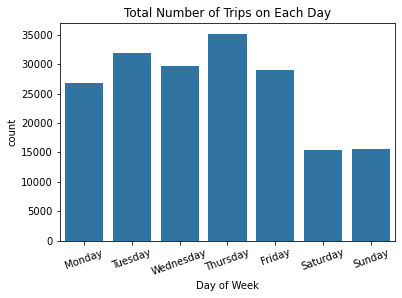

```python
sb.countplot(data=df, x='Day_of_week',order=days, color = base_color)
plt.xticks(rotation = 20)
plt.title("Total Number of Trips on Each Day")
plt.xlabel("Day of Week");
```

Thursday has the highest number of trips. This makes it the busiest day.

#### What time(s) of the day is the busiest?

```python
time_order = df['time'].value_counts().index.sort_values();
```

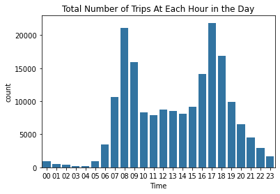

```python
sb.countplot(data=df, x="time", order=time_order, color=base_color)
plt.title("Total Number of Trips At Each Hour in the Day")
plt.xlabel("Time");
```

The stations are busiest from 8AM to 9AM and from 5PM to 6PM. These are the peak hours of these service.

### Discuss the distribution(s) of your variable(s) of interest. Were there any unusual points? Did you need to perform any transformations?

> The distribution of the duration was right skewed with some values extremely high when compared to the others. I performed a long transformation to have clearer view of the distribution. The mode of the duration is between 7 and 10 minutes.

### Of the features you investigated, were there any unusual distributions? Did you perform any operations on the data to tidy, adjust, or change the form of the data? If so, why did you do this?

> There were no unusual distributions but there were incorrect and missing values for some features, so i imputed them using mean and mode. I created new features (age, duration(min), day of week and time) because they will more relevant for getting insight.

Now, let's see if there is a relationship between the age of the members and the duration of their trips.

## Bivariate Exploration

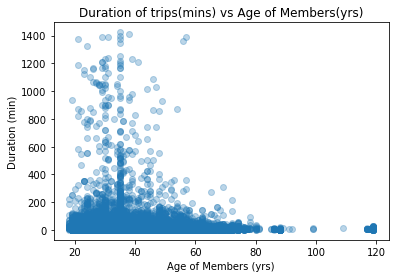

```python
plt.scatter(data=df, x='member_age', y='duration_min', alpha=0.3)
plt.xlabel("Age of Members (yrs)")
plt.ylabel("Duration (min)")
plt.title("Duration of trips(mins) vs Age of Members(yrs)")
plt.show()
```

Regardless of age, most of the trips are below 200 minutes. Trips with durations higher than 400 minutes are only found among members between the ages of 18 and 60 years. Let's zoom in and see what's going for ages 70 and above.

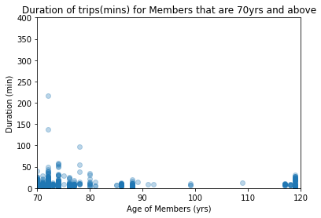

```python
plt.scatter(data=df, x='member_age', y='duration_min', alpha=0.3)
plt.xlim(70,120)
plt.ylim(0,400)
plt.xlabel("Age of Members (yrs)")
plt.ylabel("Duration (min)")
plt.title("Duration of trips(mins) for Members that are 70yrs and above")
plt.show()
```

Most of the rides for this age group are below 50 mins which isn't surprising because old people shouldn't be riding for too long.

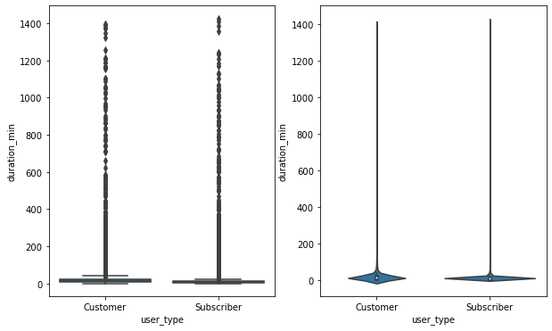

```python
fig,ax = plt.subplots(nrows=1,ncols=2, figsize = [10,6])
sb.boxplot(data=df, x='user_type',y='duration_min',ax=ax[0], color=base_color)
sb.violinplot(data=df, x='user_type',y='duration_min', ax=ax[1], color=base_color);
```

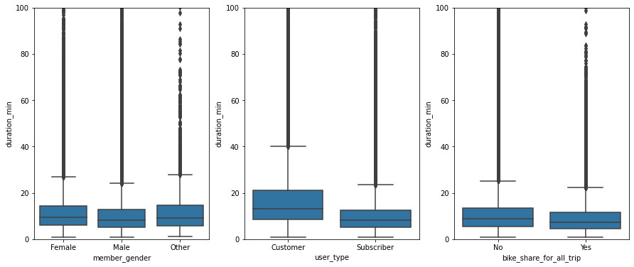

```python
fig,ax = plt.subplots(nrows=1,ncols=3, figsize = [15,6])
sb.boxplot(data=df, x='member_gender',y='duration_min',ax=ax[0], color=base_color)
sb.boxplot(data=df, x='user_type',y='duration_min',ax=ax[1], color=base_color)
sb.boxplot(data=df, x='bike_share_for_all_trip',y='duration_min',ax=ax[2], color=base_color)

for i in range(3):
    ax[i].set_ylim(0,100)
```

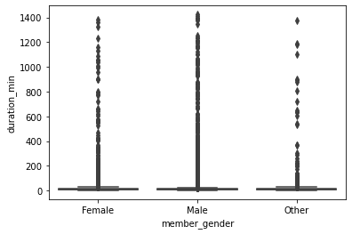

```python
sb.boxplot(data=df, x='member_gender',y='duration_min', color=base_color);
```

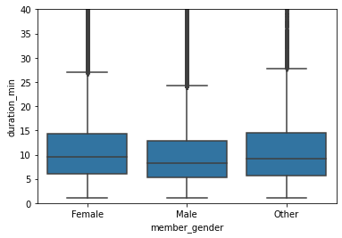

```python
sb.boxplot(data=df, x='member_gender',y='duration_min', color=base_color)
plt.ylim(0,40);
```

On what day does the average trip take the longest?

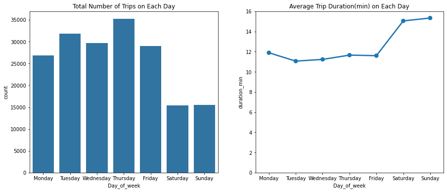

```python
fig,ax = plt.subplots(nrows=1,ncols=2, figsize = [15,6])
sb.countplot(data=df, x='Day_of_week',order=days, color = base_color, ax=ax[0])
# plt.xticks(rotation = 20)
ax[0].set_title("Total Number of Trips on Each Day")
plt.xlabel("Day of Week");
sb.pointplot(data=df, x='Day_of_week', y='duration_min', order=days, ci=None, ax=ax[1])
ax[1].set_ylim(0,16)
ax[1].set_title("Average Trip Duration(min) on Each Day")
plt.show()
```

The average trip duration is longer on weekends. Sunday has the highest average trip duration which is 15.32 mins and that of Saturday is 15.04 mins.

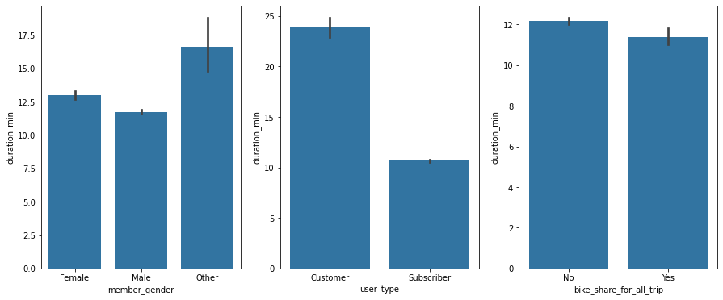

```python
fig,ax = plt.subplots(nrows=1,ncols=3, figsize = [15,6])

sb.barplot(data=df, x='member_gender', y="duration_min",color=base_color, ax=ax[0])
sb.barplot(data=df, x='user_type', y="duration_min",color=base_color, ax=ax[1])
sb.barplot(data=df, x='bike_share_for_all_trip', y="duration_min",color=base_color, ax=ax[2]);
```

Other genders have an average duration of 16.6 mins, then female, 13.0 mins and male,11.7 mins.

Customers have a higher average duration which is 23.9 mins than subscribers who have an average duration of 10.7 mins

##### Do any of the other features have relationship with themselves?

Let's see.

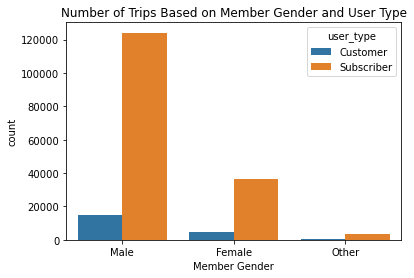

```python
sb.countplot(data=df, x='member_gender', order=bike_data['member_gender'].value_counts().index, hue="user_type")
plt.title("Number of Trips Based on Member Gender and User Type")
plt.xlabel("Member Gender")
plt.show()
```

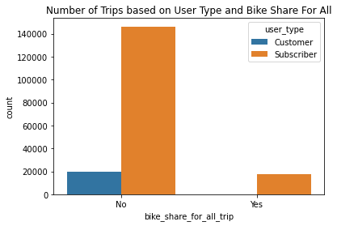

```python
sb.countplot(data=df, x='bike_share_for_all_trip', hue='user_type')
plt.title("Number of Trips based on User Type and Bike Share For All");
```

There are no customers who had bike share for all trips. All members that have bike share for all trips are subscribers.

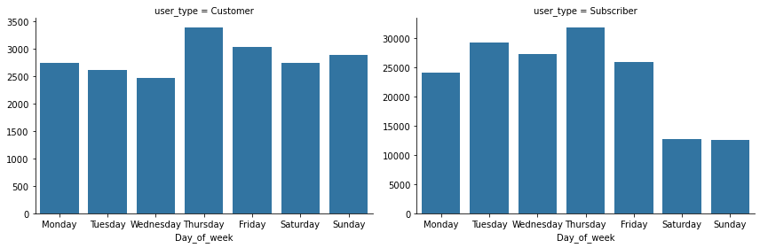

```python
g = sb.FacetGrid(data=df, col= 'user_type', height=4, sharey=False, aspect=1.5)
g.map(sb.countplot, 'Day_of_week',order=days);
```

Subscribers have the least amount of trips on Weekends(Saturday and Sunday).

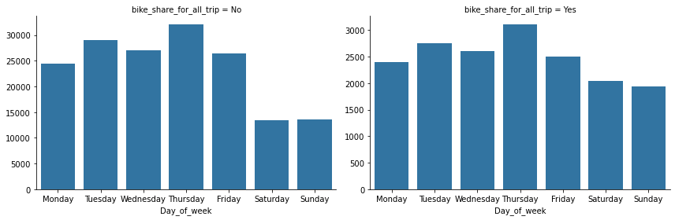

```python
g = sb.FacetGrid(data=df, col= 'bike_share_for_all_trip', height=4, sharey=False, aspect=1.5)
g.map(sb.countplot, 'Day_of_week',order=days);
```

### Talk about some of the relationships you observed in this part of the investigation. How did the feature(s) of interest vary with other features in the dataset?

> Based on day of the week, Weekends(Saturday and Sunday) have the highest average trip durations. Based on user_types, customers have a higher average trip duration than subscribers. Other genders tend to have a higher average trip duration than females and males. Bike share for all trips have a lower average duration than ordinary trips.

### Did you observe any interesting relationships between the other features (not the main feature(s) of interest)?

> On examining the other features, I observed that there are no customers who had bike share for all trips and Subscribers have the least amount of trips on Weekends(Saturday and Sunday).

## Multivariate Exploration

> Create plots of three or more variables to investigate your data even further. Make sure that your investigations are justified, and follow from your work in the previous sections.

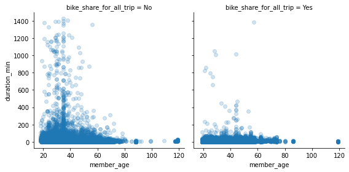

```python
g = sb.FacetGrid(data=df, col='bike_share_for_all_trip', height=4)
g.map(plt.scatter,'member_age', 'duration_min', alpha=0.2);
```

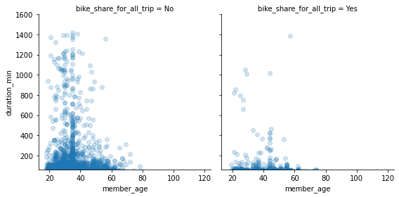

```python
g = sb.FacetGrid(data=df, col='bike_share_for_all_trip', height=4)
g.map(plt.scatter,'member_age', 'duration_min', alpha=0.2)
g.set(ylim=(60,1600));
```

Very few bike share for all trips have a duration more than 60 mins(1 hour).

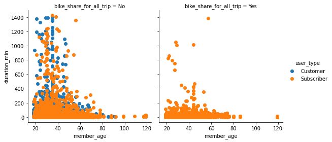

```python
g = sb.FacetGrid(data=df, col='bike_share_for_all_trip', height=4, hue="user_type")
g.map(plt.scatter,'member_age', 'duration_min')
g.add_legend()
```

As we saw earlier, all the bike share for all trips are trips from subscribers. It seems like only subscribers can have access to bike share for all.

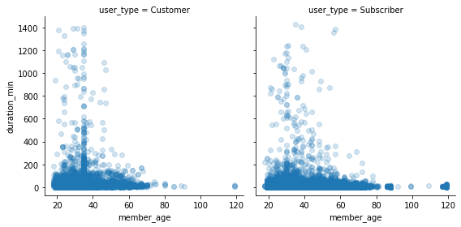

```python
g = sb.FacetGrid(data=df, col='user_type', height=4)
g.map(plt.scatter,'member_age', 'duration_min', alpha=0.2)
```

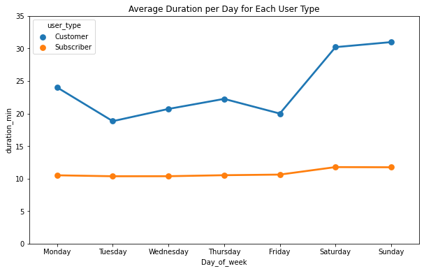

```python
plt.figure(figsize=(10,6))
sb.pointplot(data=df, x='Day_of_week', y='duration_min', order=days, hue = "user_type", ci=None)
plt.ylim(0,35)
plt.title("Average Duration per Day for Each User Type")
plt.show()
```

On every day of the week, Customers have a higher average trip duration than subscribers. For both user types, average trip duration is highest on weekends (Saturday and Sunday).

### Talk about some of the relationships you observed in this part of the investigation. Were there features that strengthened each other in terms of looking at your feature(s) of interest?

> Bike share for all trips stregthened the relationship between trip duration and member age and while user type stregthened the relationship between trip duration and day of the week.

### Were there any interesting or surprising interactions between features?

> Very few bike share for all trips have a duration more than 60 mins(1 hour). Also, all the bike share for all trips are trips from subscribers. Even though, number of trips are the lowest on weekends, the highest average trip duration is on these days.

## Conclusions

> After wrangling the data and doing some feature engineering(creating new features from the original features), these are my main findings:
> - The modal trip duration is between 7 and 10 minutes.
> - Most of the members are between the age 25 and 40 years. The modal age is between 29 and 32 years.
> - Most of the members of fordgobike trip are male subscribers.
> - Thursday has the highest number of trips.
> - The stations are busiest from 8AM to 9AM and from 5PM to 6PM.
> - All members that have bike share for all trips are subscribers.
> - Subscribers have the least amount of trips on weekends.
> - The average trip duration is longer on weekends
> - Very few bike share for all trips have a duration more than 60 mins(1 hour).
> - On every day of the week, Customers have a higher average trip duration than subscribers.